# Fall 2022: Final Project

Shaoyu Huang

2022-12-12

```r
library(tidyverse)
library(ggpubr)
```

```r
library(caret)
```

# **Exploration**

## Read data

The code chunk below reads in the final project data.

```r
df <- readr::read_csv("fall2022_finalproject.csv", col_names = TRUE)
df %>% glimpse()
```

```
## Rows: 1,252
## Columns: 11
## $ x1     <dbl> 0.025878, 0.030768, 0.019325, 0.306212, 0.031296, 0.031073, 0.0…
## $ x2     <dbl> 0.255934, 0.261575, 0.020877, 0.033379, 0.259342, 0.027119, 0.0…
## $ x3     <dbl> 0.492830, 0.498460, 0.258360, 0.255385, 0.264387, 0.260915, 0.0…
## $ x4     <dbl> 0.012770, 0.055779, 0.012424, 0.056190, 0.056594, 0.055192, 0.0…
## $ v1     <dbl> 0.275651, 0.343204, 4.998508, 5.090153, 5.031107, 9.977407, 0.2…
## $ v2     <dbl> 0.033657, 0.027082, 0.030259, 0.052342, 0.517705, 0.532436, 1.0…
## $ v3     <dbl> 1.166214, 1.260579, 1.298285, 1.322005, 1.368195, 1.298797, 1.1…
## $ v4     <dbl> 0.408402, 0.664248, 0.412870, 0.652111, 0.533701, 0.857509, 0.6…
## $ v5     <dbl> 0.525226, 2.866343, 0.409007, 0.861594, 6.451933, 0.958574, 0.2…
## $ m      <chr> "A", "A", "A", "A", "A", "A", "A", "A", "A", "A", "A", "A", "A"…
## $ output <dbl> 0.786, 0.730, 0.996, 0.326, 0.735, 0.954, 0.969, 0.986, 0.874, …
```

## Modify data

### Transform output

```r
df <- df %>% mutate(y = boot::logit(output), outcome = ifelse(output < 0.33, 'event', 'non_event'), outcome = factor(outcome, levels = c("event", "non_event"))) %>%  glimpse()
```

```
## Rows: 1,252
## Columns: 13
## $ x1      <dbl> 0.025878, 0.030768, 0.019325, 0.306212, 0.031296, 0.031073, 0.…
## $ x2      <dbl> 0.255934, 0.261575, 0.020877, 0.033379, 0.259342, 0.027119, 0.…
## $ x3      <dbl> 0.492830, 0.498460, 0.258360, 0.255385, 0.264387, 0.260915, 0.…
## $ x4      <dbl> 0.012770, 0.055779, 0.012424, 0.056190, 0.056594, 0.055192, 0.…
## $ v1      <dbl> 0.275651, 0.343204, 4.998508, 5.090153, 5.031107, 9.977407, 0.…
## $ v2      <dbl> 0.033657, 0.027082, 0.030259, 0.052342, 0.517705, 0.532436, 1.…
## $ v3      <dbl> 1.166214, 1.260579, 1.298285, 1.322005, 1.368195, 1.298797, 1.…
## $ v4      <dbl> 0.408402, 0.664248, 0.412870, 0.652111, 0.533701, 0.857509, 0.…
## $ v5      <dbl> 0.525226, 2.866343, 0.409007, 0.861594, 6.451933, 0.958574, 0.…
## $ m       <chr> "A", "A", "A", "A", "A", "A", "A", "A", "A", "A", "A", "A", "A…
## $ output  <dbl> 0.786, 0.730, 0.996, 0.326, 0.735, 0.954, 0.969, 0.986, 0.874,…
## $ y       <dbl> 1.3009808, 0.9946226, 5.5174529, -0.7263327, 1.0201407, 3.0320…
## $ outcome <fct> non_event, non_event, non_event, event, non_event, non_event, …
```

### Add derived features

```r
df_derived <- df %>% mutate(x5 = 1-x1-x2-x3-x4, w = x2 / (x3 + x4), z = (x1 + x2) / (x4 + x5), t = v1 * v2) %>%  glimpse()
```

```
## Rows: 1,252
## Columns: 17
## $ x1      <dbl> 0.025878, 0.030768, 0.019325, 0.306212, 0.031296, 0.031073, 0.…
## $ x2      <dbl> 0.255934, 0.261575, 0.020877, 0.033379, 0.259342, 0.027119, 0.…
## $ x3      <dbl> 0.492830, 0.498460, 0.258360, 0.255385, 0.264387, 0.260915, 0.…
## $ x4      <dbl> 0.012770, 0.055779, 0.012424, 0.056190, 0.056594, 0.055192, 0.…
## $ v1      <dbl> 0.275651, 0.343204, 4.998508, 5.090153, 5.031107, 9.977407, 0.…
## $ v2      <dbl> 0.033657, 0.027082, 0.030259, 0.052342, 0.517705, 0.532436, 1.…
## $ v3      <dbl> 1.166214, 1.260579, 1.298285, 1.322005, 1.368195, 1.298797, 1.…
## $ v4      <dbl> 0.408402, 0.664248, 0.412870, 0.652111, 0.533701, 0.857509, 0.…
## $ v5      <dbl> 0.525226, 2.866343, 0.409007, 0.861594, 6.451933, 0.958574, 0.…
## $ m       <chr> "A", "A", "A", "A", "A", "A", "A", "A", "A", "A", "A", "A", "A…
## $ output  <dbl> 0.786, 0.730, 0.996, 0.326, 0.735, 0.954, 0.969, 0.986, 0.874,…
## $ y       <dbl> 1.3009808, 0.9946226, 5.5174529, -0.7263327, 1.0201407, 3.0320…
## $ outcome <fct> non_event, non_event, non_event, event, non_event, non_event, …
## $ x5      <dbl> 0.212588, 0.153418, 0.689014, 0.348834, 0.388381, 0.625701, 0.…
## $ w       <dbl> 0.50619858, 0.47195344, 0.07709835, 0.10712990, 0.80796683, 0.…
## $ z       <dbl> 1.25050808, 1.39745312, 0.05731369, 0.83844661, 0.65315580, 0.…
## $ t       <dbl> 0.009277586, 0.009294651, 0.151249854, 0.266428788, 2.60462924…
```

## Visualize the data

### Visualize features

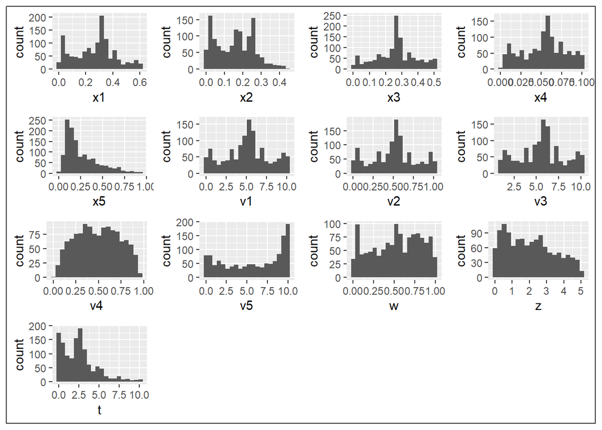

```r
h_x1 <- df_derived %>%
  ggplot() +
  geom_histogram(aes(x = x1), bins=20)
h_x2 <- df_derived %>%
  ggplot() +
  geom_histogram(aes(x = x2), bins=20)
h_x3 <- df_derived %>%
  ggplot() +
  geom_histogram(aes(x = x3), bins=20)
h_x4 <- df_derived %>%
  ggplot() +
  geom_histogram(aes(x = x4), bins=20)
h_x5 <- df_derived %>%
  ggplot() +
  geom_histogram(aes(x = x5), bins=20)
h_v1 <- df_derived %>%
  ggplot() +
  geom_histogram(aes(x = v1), bins=20)
h_v2 <- df_derived %>%
  ggplot() +
  geom_histogram(aes(x = v2), bins=20)
h_v3 <- df_derived %>%
  ggplot() +
  geom_histogram(aes(x = v3), bins=20)
h_v4 <- df_derived %>%
  ggplot() +
  geom_histogram(aes(x = v4), bins=20)
h_v5 <- df_derived %>%
  ggplot() +
  geom_histogram(aes(x = v5), bins=20)
h_w <- df_derived %>%
  ggplot() +
  geom_histogram(aes(x = w), bins=20)
h_z <- df_derived %>%
  ggplot() +
  geom_histogram(aes(x = z), bins=20)
h_t <- df_derived %>%
  ggplot() +
  geom_histogram(aes(x = t), bins=20)
ggarrange(h_x1, h_x2, h_x3, h_x4, h_x5, h_v1, h_v2, h_v3, h_v4, h_v5, h_w, h_z, h_t, nrow = 4, ncol = 4) +
  theme_bw()
```

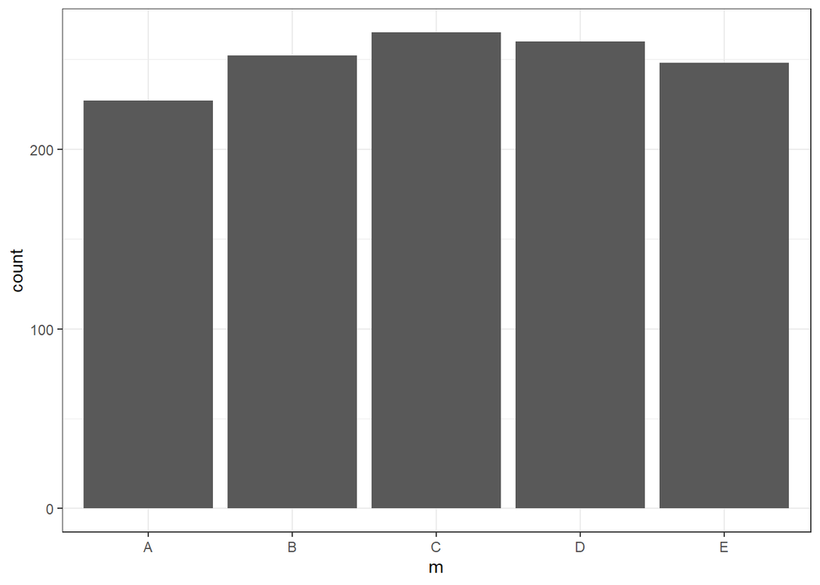

```r
df_derived %>%
  ggplot() +
  geom_bar(aes(x = m)) +
  theme_bw()
```

### Visualize outputs

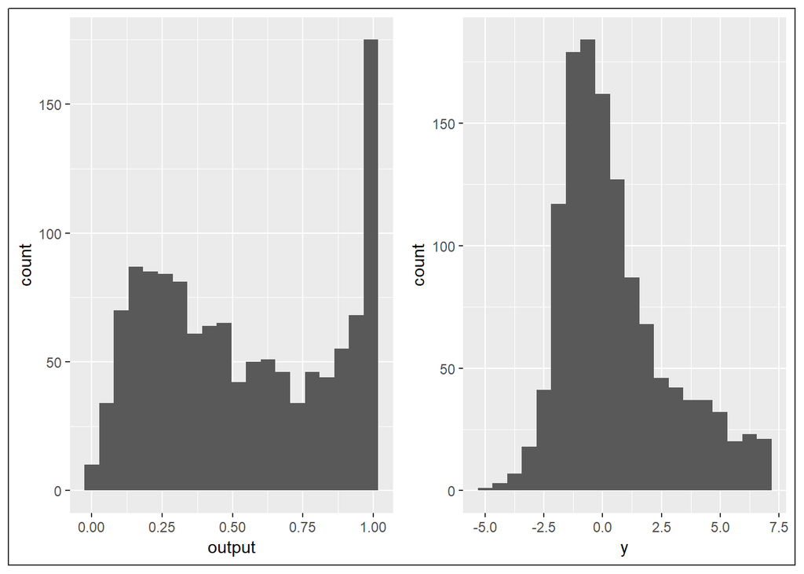

```r
h_output <- df %>%
  ggplot() +
  geom_histogram(aes(x = output), bins = 20)
h_y <- df %>%
  ggplot() +
  geom_histogram(aes(x = y), bins = 20)
ggarrange(h_output, h_y, ncol = 2) +
  theme_bw()
```

## Distribution with respect to `m`

### Features with respect to `m`

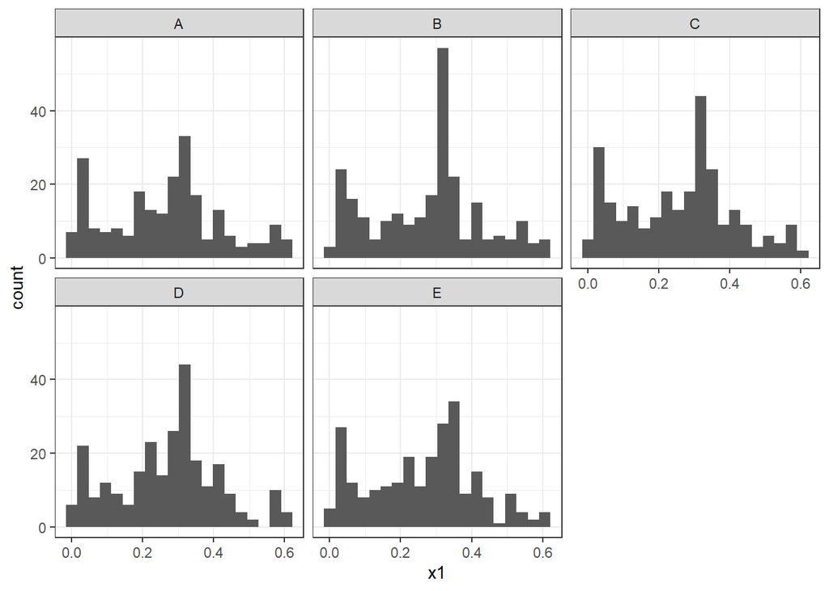

```r
df_derived %>%
  ggplot() +
  geom_histogram(aes(x = x1), bins=20) +
  facet_wrap(~m) +
  theme_bw()
```

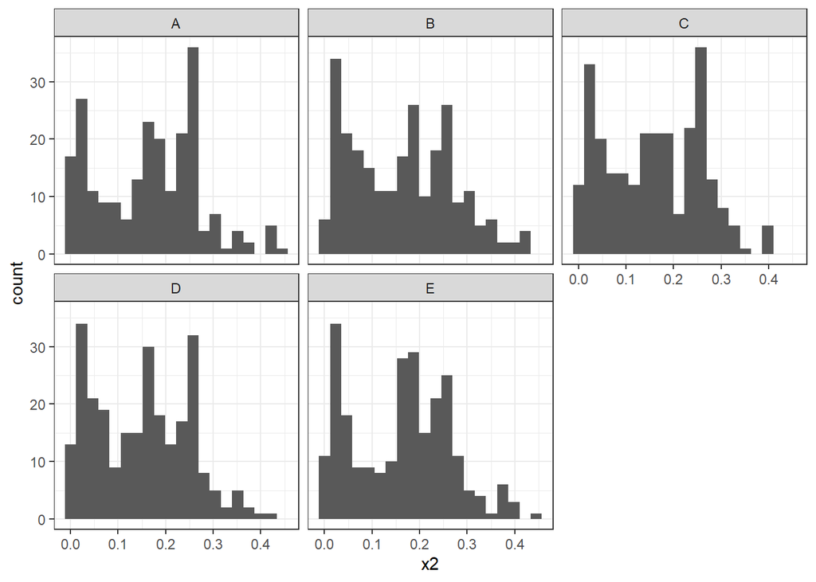

```r
df_derived %>%
  ggplot() +
  geom_histogram(aes(x = x2), bins=20) +
  facet_wrap(~m) +
  theme_bw()
```

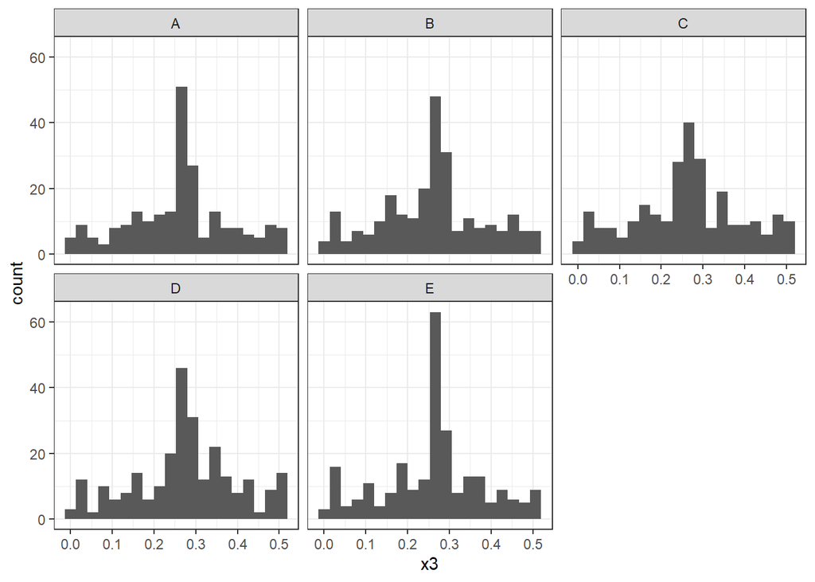

```r
df_derived %>%
  ggplot() +
  geom_histogram(aes(x = x3), bins=20) +
  facet_wrap(~m) +
  theme_bw()
```

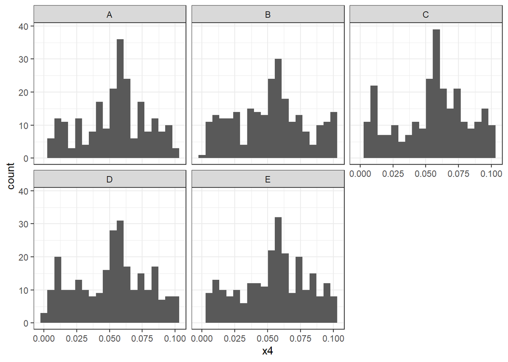

```r
df_derived %>%
  ggplot() +
  geom_histogram(aes(x = x4), bins=20) +
  facet_wrap(~m) +
  theme_bw()
```

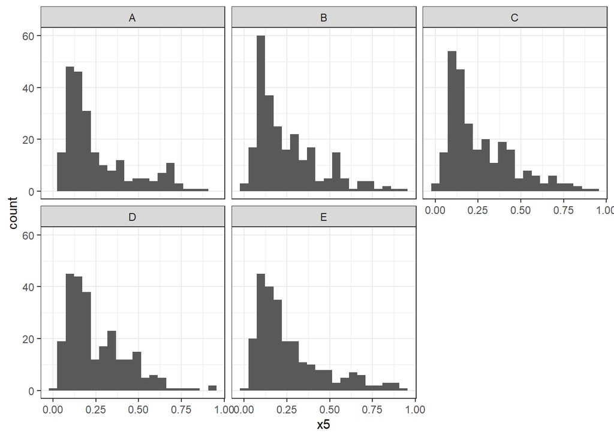

```r
df_derived %>%
  ggplot() +
  geom_histogram(aes(x = x5), bins=20) +
  facet_wrap(~m) +
  theme_bw()
```

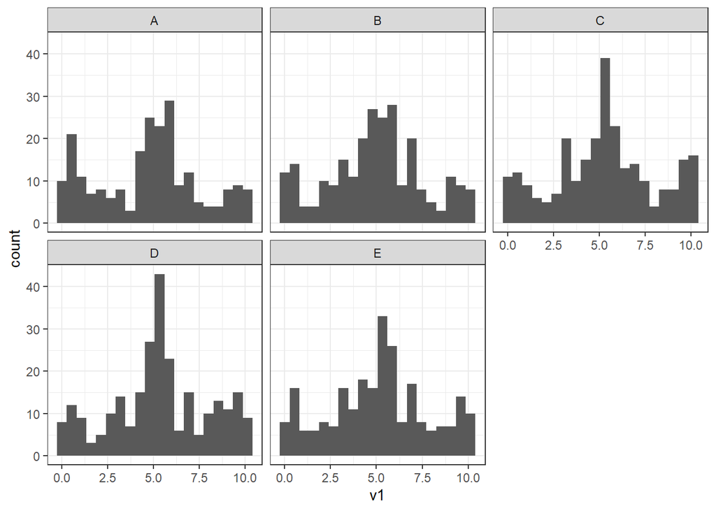

```r
df_derived %>%
  ggplot() +
  geom_histogram(aes(x = v1), bins=20) +
  facet_wrap(~m) +
  theme_bw()
```

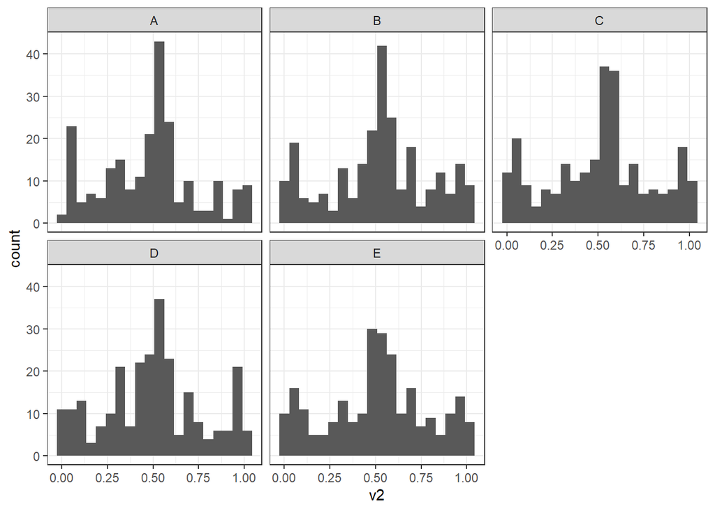

```r
df_derived %>%
  ggplot() +
  geom_histogram(aes(x = v2), bins=20) +
  facet_wrap(~m) +
  theme_bw()
```

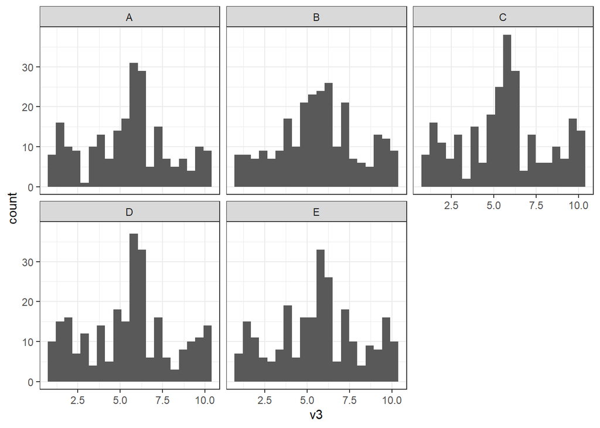

```r
df_derived %>%
  ggplot() +
  geom_histogram(aes(x = v3), bins=20) +
  facet_wrap(~m) +
  theme_bw()
```

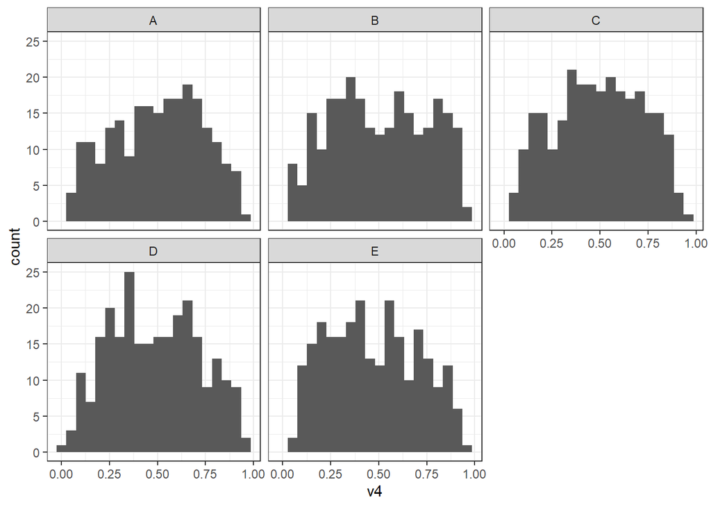

```r
df_derived %>%
  ggplot() +
  geom_histogram(aes(x = v4), bins=20) +
  facet_wrap(~m) +
  theme_bw()
```

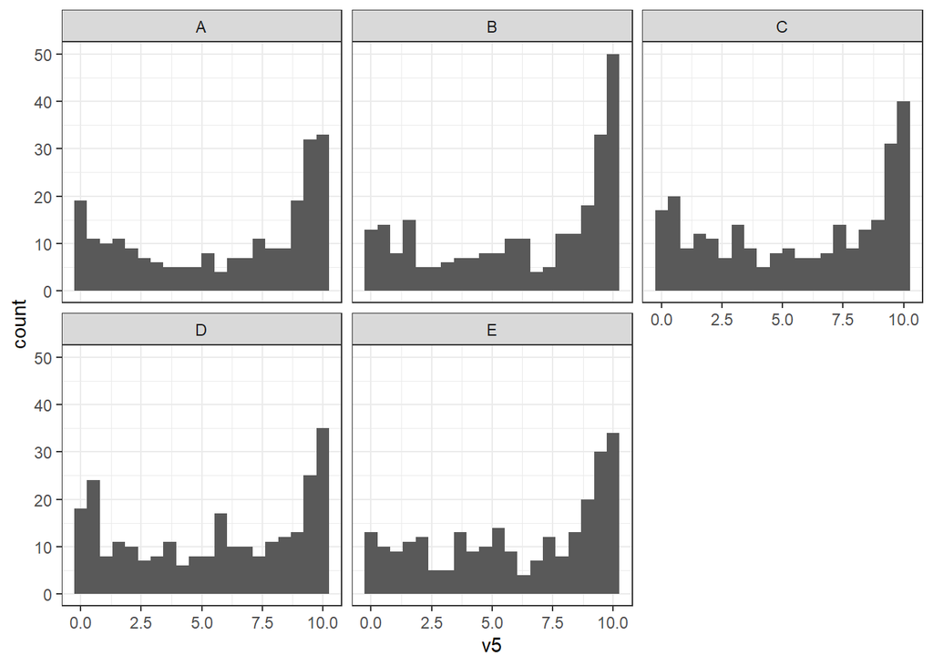

```r
df_derived %>%
  ggplot() +
  geom_histogram(aes(x = v5), bins=20) +
  facet_wrap(~m) +
  theme_bw()
```

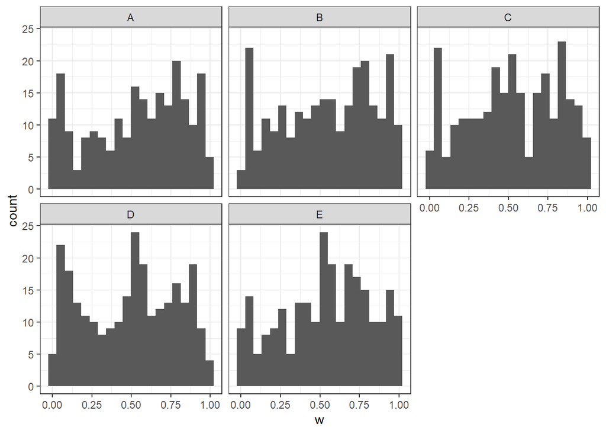

```r
df_derived %>%
  ggplot() +
  geom_histogram(aes(x = w), bins=20) +
  facet_wrap(~m) +
  theme_bw()
```

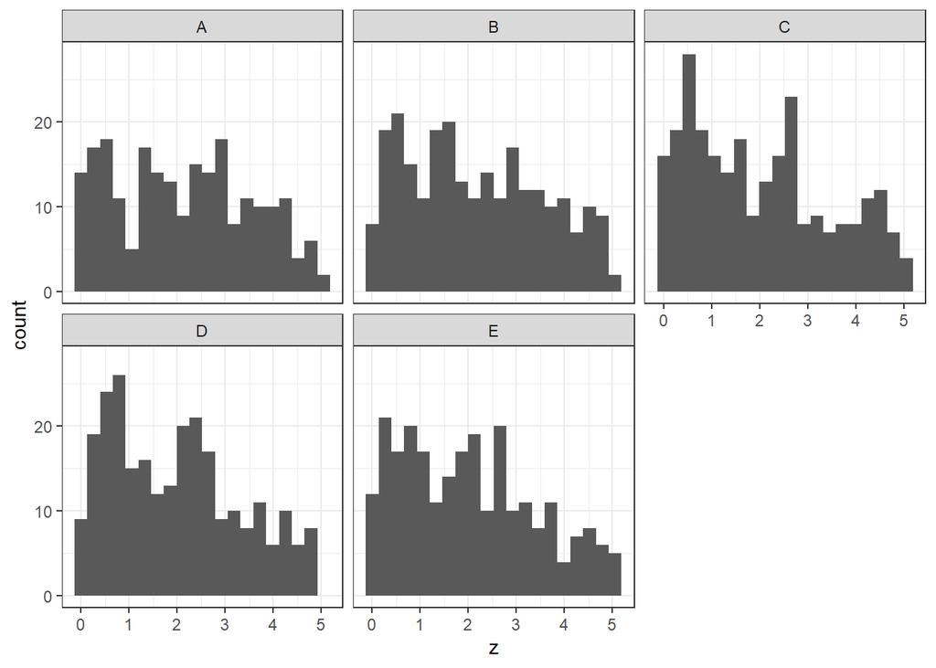

```r
df_derived %>%
  ggplot() +
  geom_histogram(aes(x = z), bins=20) +
  facet_wrap(~m) +
  theme_bw()
```

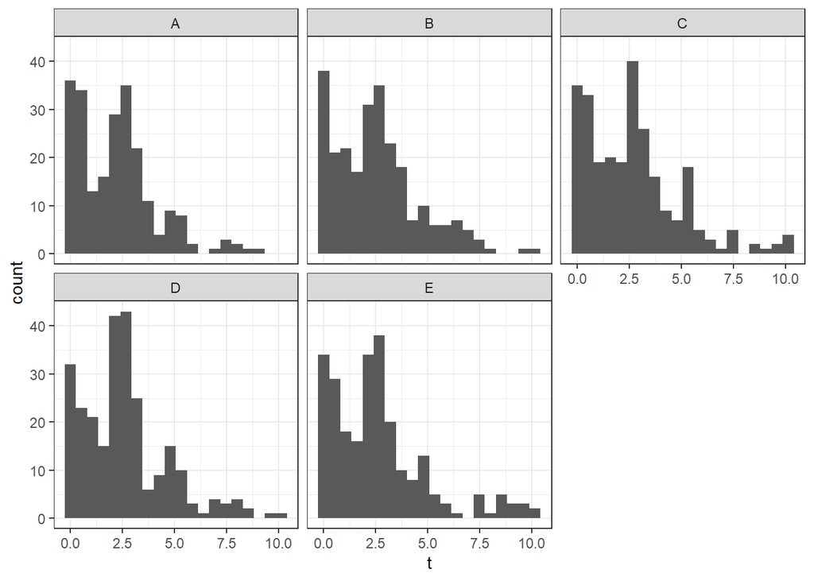

```r
df_derived %>%
  ggplot() +
  geom_histogram(aes(x = t), bins=20) +
  facet_wrap(~m) +
  theme_bw()
```

There are no obvious differences in input values based on the discrete groups.

### Output with respect to `m`

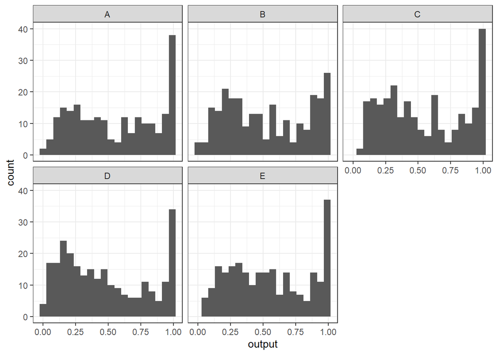

```r
df_derived %>%
  ggplot() +
  geom_histogram(aes(x = output), bins=20) +
  facet_wrap(~m) +
  theme_bw()
```

There are no obvious differences in `output` based on the discrete groups.

## Relation between features

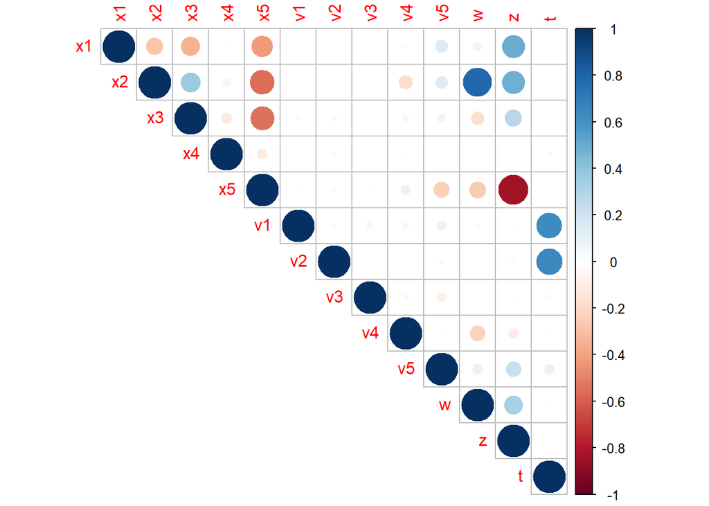

```r
df_derived %>%
  select(starts_with('x'), starts_with('v'), c(w, z, t)) %>%
  cor() %>%
  corrplot::corrplot(type = 'upper')
```

The derived features of course are correlated to the inputs. For the inputs part, `x1,x2,x3` have some correlations.

## Relation between output and features

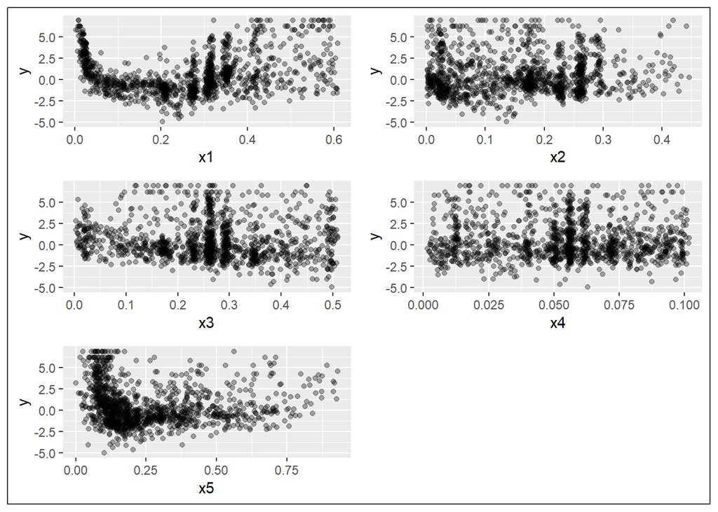

```r
p_x1 <- df_derived %>% ggplot(mapping = aes(x = x1, y = y)) +
  geom_point(alpha = 0.33)
p_x2 <- df_derived %>% ggplot(mapping = aes(x = x2, y = y)) +
  geom_point(alpha = 0.33)
p_x3 <- df_derived %>% ggplot(mapping = aes(x = x3, y = y)) +
  geom_point(alpha = 0.33)
p_x4 <- df_derived %>% ggplot(mapping = aes(x = x4, y = y)) +
  geom_point(alpha = 0.33)
p_x5 <- df_derived %>% ggplot(mapping = aes(x = x5, y = y)) +
  geom_point(alpha = 0.33)
p_v1 <- df_derived %>% ggplot(mapping = aes(x = v1, y = y)) +
  geom_point(alpha = 0.33)
p_v2 <- df_derived %>% ggplot(mapping = aes(x = v2, y = y)) +
  geom_point(alpha = 0.33)
p_v3 <- df_derived %>% ggplot(mapping = aes(x = v3, y = y)) +
  geom_point(alpha = 0.33)
p_v4 <- df_derived %>% ggplot(mapping = aes(x = v4, y = y)) +
  geom_point(alpha = 0.33)
p_v5 <- df_derived %>% ggplot(mapping = aes(x = v5, y = y)) +
  geom_point(alpha = 0.33)
p_w <- df_derived %>% ggplot(mapping = aes(x = w, y = y)) +
  geom_point(alpha = 0.33)
p_z <- df_derived %>% ggplot(mapping = aes(x = z, y = y)) +
  geom_point(alpha = 0.33)
p_t <- df_derived %>% ggplot(mapping = aes(x = t, y = y)) +
  geom_point(alpha = 0.33)
p_m <- df_derived %>% ggplot(mapping = aes(x = m, y = y)) +
  geom_point(alpha = 0.33)
ggarrange(p_x1, p_x2, p_x3, p_x4, p_x5, nrow = 3, ncol=2) +
  theme_bw()
```

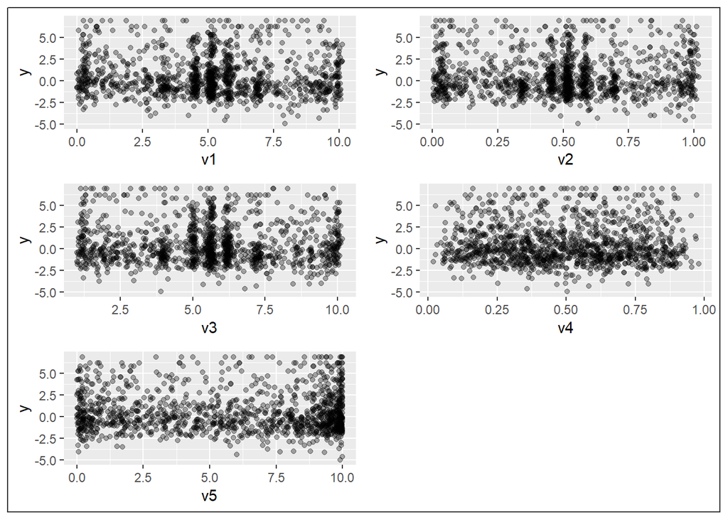

```r
ggarrange(p_v1, p_v2, p_v3, p_v4, p_v5, nrow = 3, ncol=2) +
  theme_bw()
```

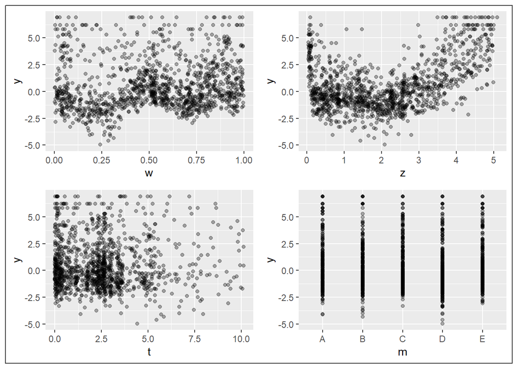

```r
ggarrange(p_w, p_z, p_t, p_m, nrow = 2, ncol=2) +
  theme_bw()
```

## Relation between binary outcome and features

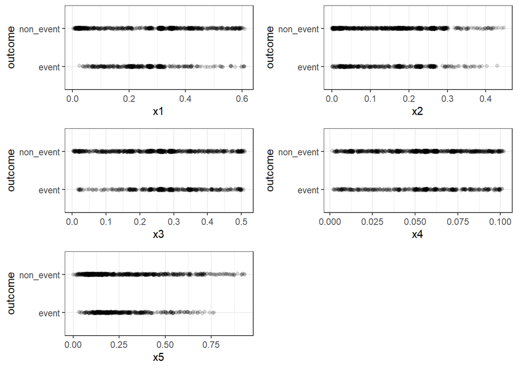

```r
b_x1 <- df_derived %>%
  ggplot(mapping = aes(x = x1, y = outcome)) +
  geom_jitter(height = 0.02, width = 0, alpha=0.15) +
  theme_bw()
b_x2 <- df_derived %>%
  ggplot(mapping = aes(x = x2, y = outcome)) +
  geom_jitter(height = 0.02, width = 0, alpha=0.15) +
  theme_bw()
b_x3 <- df_derived %>%
  ggplot(mapping = aes(x = x3, y = outcome)) +
  geom_jitter(height = 0.02, width = 0, alpha=0.15) +
  theme_bw()
b_x4 <- df_derived %>%
  ggplot(mapping = aes(x = x4, y = outcome)) +
  geom_jitter(height = 0.02, width = 0, alpha=0.15) +
  theme_bw()
b_x5 <- df_derived %>%
  ggplot(mapping = aes(x = x5, y = outcome)) +
  geom_jitter(height = 0.02, width = 0, alpha=0.15) +
  theme_bw()
b_v1 <- df_derived %>%
  ggplot(mapping = aes(x = v1, y = outcome)) +
  geom_jitter(height = 0.02, width = 0, alpha=0.15) +
  theme_bw()
b_v2 <- df_derived %>%
  ggplot(mapping = aes(x = v2, y = outcome)) +
  geom_jitter(height = 0.02, width = 0, alpha=0.15) +
  theme_bw()
b_v3 <- df_derived %>%
  ggplot(mapping = aes(x = v3, y = outcome)) +
  geom_jitter(height = 0.02, width = 0, alpha=0.15) +
  theme_bw()
b_v4 <- df_derived %>%
  ggplot(mapping = aes(x = v4, y = outcome)) +
  geom_jitter(height = 0.02, width = 0, alpha=0.15) +
  theme_bw()
b_v5 <- df_derived %>%
  ggplot(mapping = aes(x = v5, y = outcome)) +
  geom_jitter(height = 0.02, width = 0, alpha=0.15) +
  theme_bw()
b_w <- df_derived %>%
  ggplot(mapping = aes(x = w, y = outcome)) +
  geom_jitter(height = 0.02, width = 0, alpha=0.15) +
  theme_bw()
b_z <- df_derived %>%
  ggplot(mapping = aes(x = z, y = outcome)) +
  geom_jitter(height = 0.02, width = 0, alpha=0.15) +
  theme_bw()
b_t <- df_derived %>%
  ggplot(mapping = aes(x = t, y = outcome)) +
  geom_jitter(height = 0.02, width = 0, alpha=0.15) +
  theme_bw()
ggarrange(b_x1, b_x2, b_x3, b_x4, b_x5, nrow = 3, ncol = 2)
```

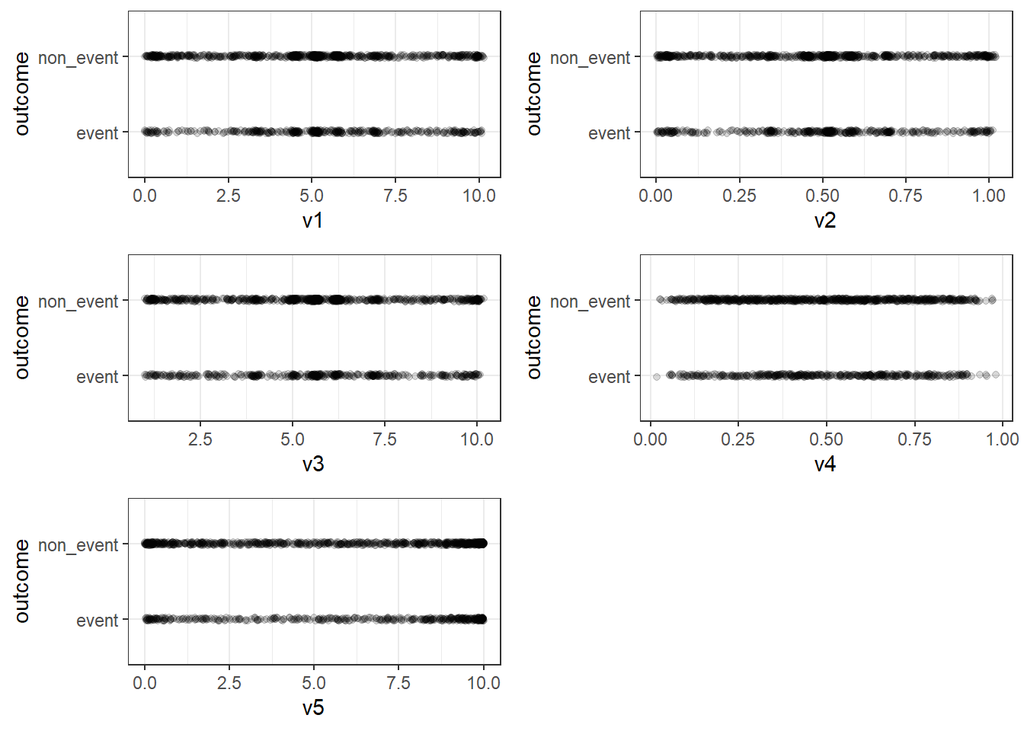

```r
ggarrange(b_v1, b_v2, b_v3, b_v4, b_v5, nrow = 3, ncol = 2)
```

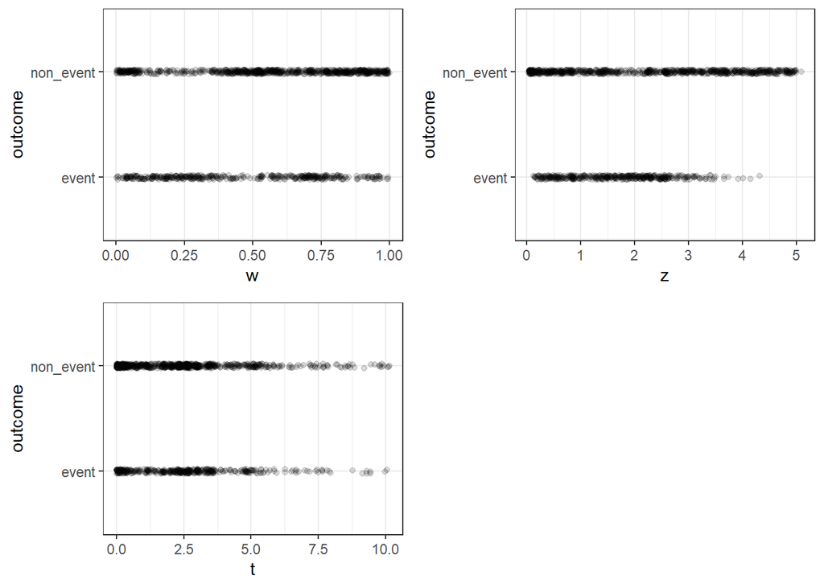

```r
ggarrange(b_w, b_z, b_t, nrow = 2, ncol = 2)
```

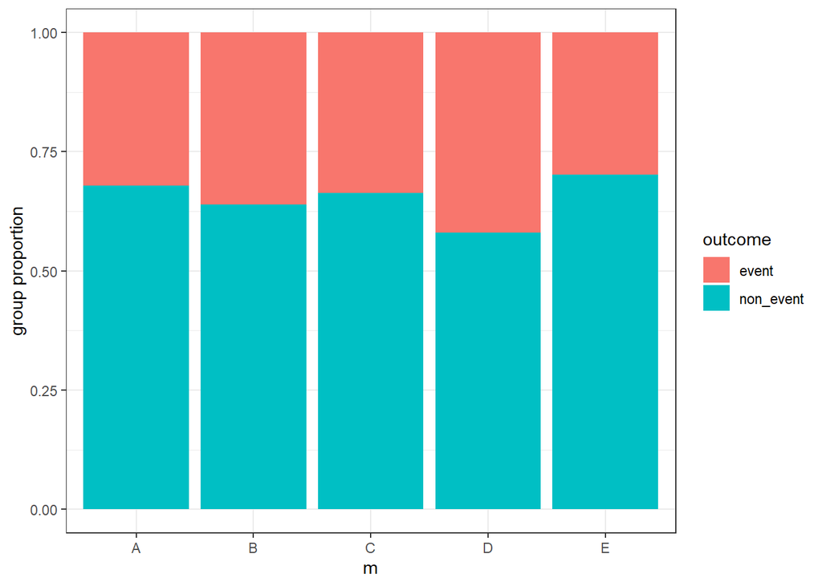

```r
df_derived %>%
  ggplot(mapping = aes(x = m)) +
  geom_bar(mapping = aes(fill = outcome),
           position = 'fill') +
  labs(y = 'group proportion') +
  theme_bw()
```

# **Regression**

```r
library(coefplot)
```

## Linear models

First we use `lm()` to fit linear models.

### Base features

`mod_1, mod_2` and `mod_3` are models using *base features*.

All linear additive features:

```r
mod_1 <- lm(y ~ x1 + x2 + x3 + x4 + v1 + v2 + v3 + v4 + v5 + m, data = df)
```

Interaction of the categorical input with all continuous inputs:

```r
mod_2 <- lm(y ~ m * (x1 + x2 + x3 + x4 + v1 + v2 + v3 + v4 + v5), data = df)
```

All pair-wise interactions of the continuous inputs:

```r
mod_3 <- lm(y ~ (x1 + x2 + x3 + x4 + v1 + v2 + v3 + v4 + v5) * (x1 + x2 + x3 + x4 + v1 + v2 + v3 + v4 + v5), data = df)
```

### Expanded features

`mod_4, mod_5` and `mod_6` are models using *expanded features*.

Linear additive features:

```r
mod_4 <- lm(y ~ x1 + x2 + x3 + x4 + v1 + v2 + v3 + v4 + v5 + m + w + z + t, data = df_derived)
```

Interaction of the categorical input with continuous features:

```r
mod_5 <- lm(y ~ m * (x1 + x2 + x3 + x4 + v1 + v2 + v3 + v4 + v5 + w + z + t), data = df_derived)
```

Pair-wise interactions between the continuous features:

```r
mod_6 <- lm(y ~ (x1 + x2 + x3 + x4 + v1 + v2 + v3 + v4 + v5 + w + z + t) * (x1 + x2 + x3 + x4 + v1 + v2 + v3 + v4 + v5 + w + z + t), data = df_derived)
```

### Linear basis functions

`mod_7, mod_8` and `mod_9` are models using *basis functions*.

Linear additive features of 3 degree-of-freedom natural spline from `x`-features and `v`-features:

```r
mod_7 <- lm(y ~ splines::ns(x1, 3) + splines::ns(x2, 3) + splines::ns(x3, 3) + splines::ns(x4, 3) + v1 + v2 + v3 + v4 + v5, data = df_derived)
```

Interaction of the categorical input with 3 degree-of-freedom natural spline from `x`-features and `v`-features:

```r
mod_8 <- lm(y ~ m * (splines::ns(x1, 3) + splines::ns(x2, 3) + splines::ns(x3, 3) + splines::ns(x4, 3) + v1 + v2 + v3 + v4 + v5), data = df_derived)
```

The linear sum of interactions between `x1, x2, x3, w` and other continuous features:

```r
mod_9 <- lm(y ~ ((x1 + x2 + x3 + w) * (x1 + x2 + x3 + w) + x4 + v1 + v2 + v3 + v4 + v5 + splines::ns(z, 3) + t), data = df_derived)
```

### Compare linear models

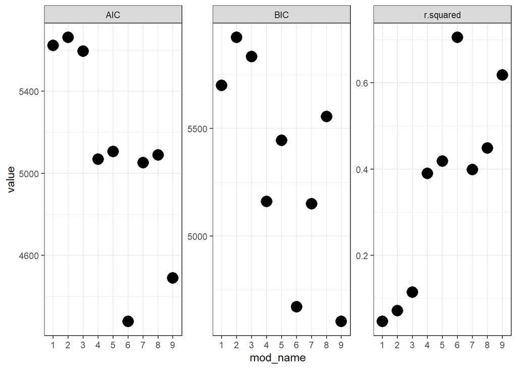

```r
extract_metrics <- function(mod, mod_name)
{
  broom::glance(mod) %>% mutate(mod_name = mod_name)
}
all_metrics <- purrr::map2_dfr(list(mod_1, mod_2, mod_3, mod_4, mod_5, mod_6, mod_7, mod_8, mod_9),
                               as.character(1:9),
                               extract_metrics)
all_metrics %>%
  select(mod_name, df, r.squared, AIC, BIC) %>%
  pivot_longer(!c("mod_name", "df")) %>%
  ggplot(mapping = aes(x = mod_name, y = value)) +
  geom_point(size = 5) +
  facet_wrap(~name, scales = "free_y") +
  theme_bw()
```

The `mod_6` has the best AIC and R-squared, which means it is the best model. `mod_9` also behaves well. Then `mod_7` is relatively good considering penalty from BIC.

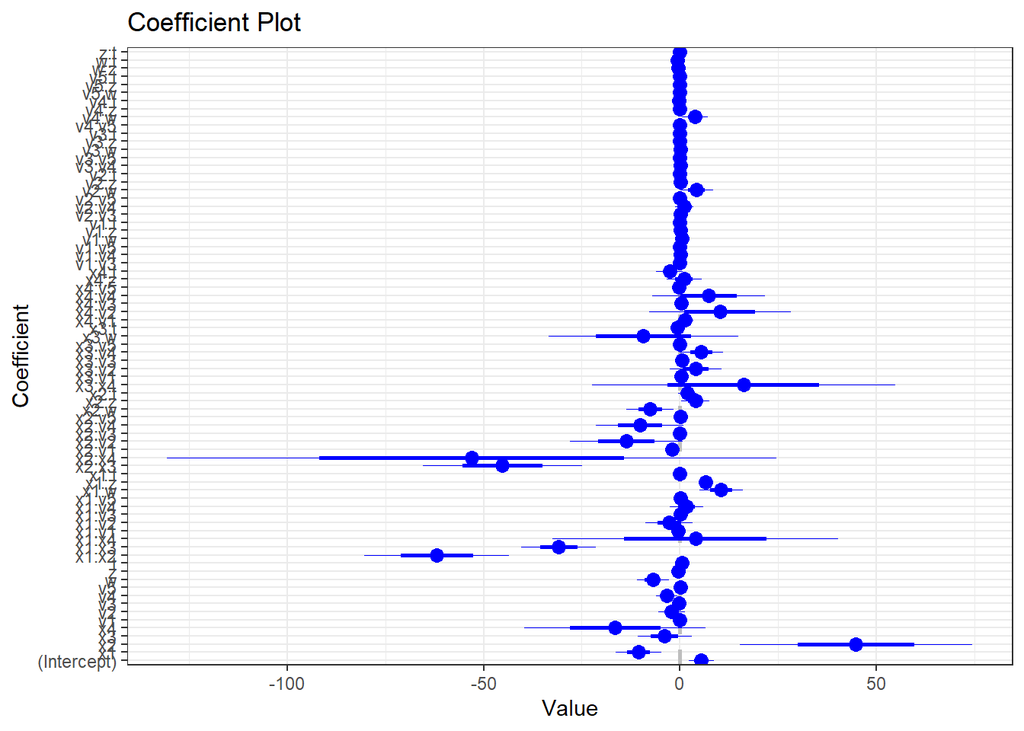

```r
mod_6 %>% coefplot::coefplot() +
  theme_bw() +
  theme(legend.position = 'none')
```

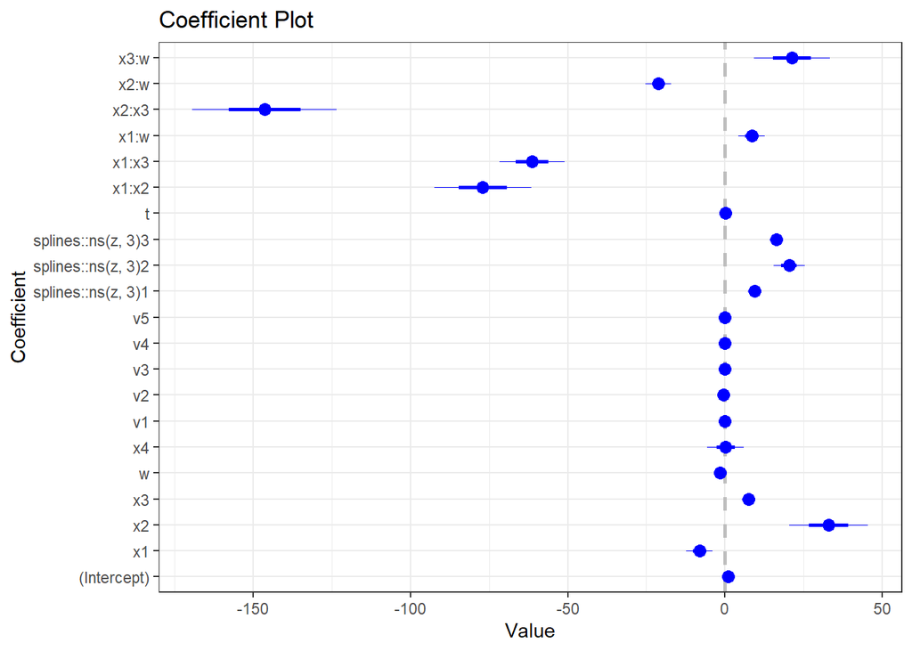

```r
mod_9 %>% coefplot::coefplot() +
  theme_bw() +
  theme(legend.position = 'none')
```

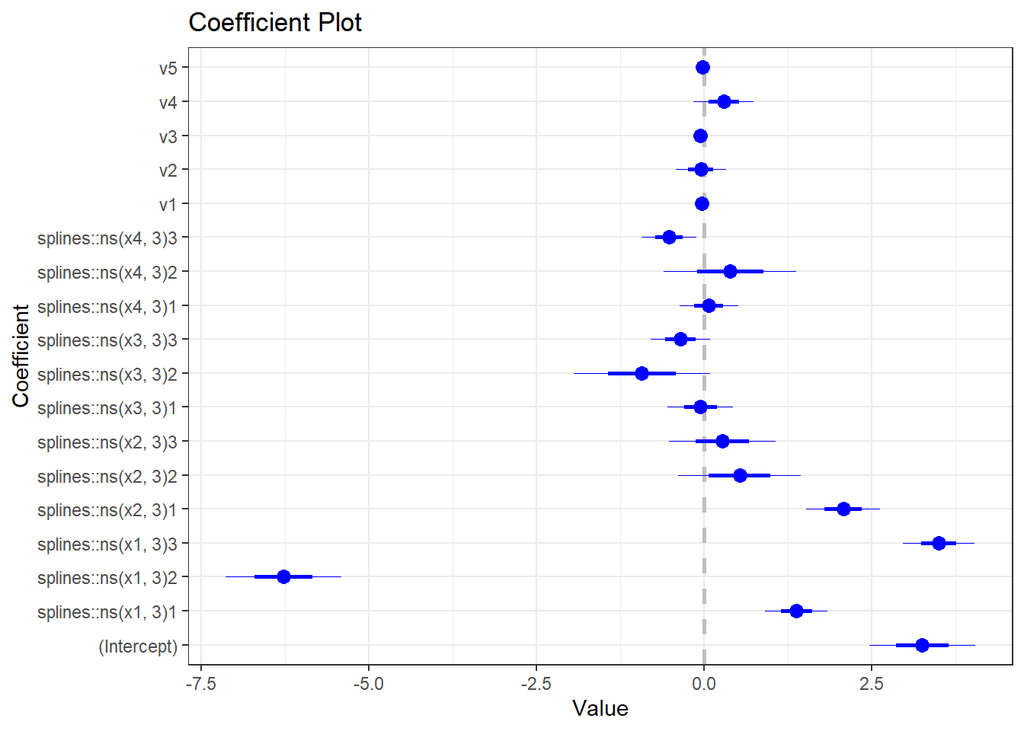

```r
mod_7 %>% coefplot::coefplot() +
  theme_bw() +
  theme(legend.position = 'none')
```

```r
mod_6 %>% summary()
```

```
##
## Call:
## lm(formula = y ~ (x1 + x2 + x3 + x4 + v1 + v2 + v3 + v4 + v5 +
##     w + z + t) * (x1 + x2 + x3 + x4 + v1 + v2 + v3 + v4 + v5 +
##     w + z + t), data = df_derived)
##
## Residuals:
##     Min      1Q  Median      3Q     Max
## -3.3739 -0.8333 -0.0010  0.8410  5.4107
##
## Coefficients: (3 not defined because of singularities)
##               Estimate Std. Error t value Pr(>|t|)
## (Intercept)  5.444e+00  1.570e+00   3.467 0.000545 ***
## x1          -1.056e+01  2.888e+00  -3.658 0.000265 ***
## x2           4.482e+01  1.480e+01   3.029 0.002504 **
## x3          -3.919e+00  3.457e+00  -1.134 0.257180
## x4          -1.652e+01  1.157e+01  -1.428 0.153455
## v1          -1.702e-01  1.843e-01  -0.924 0.355729
## v2          -2.117e+00  1.713e+00  -1.236 0.216780
## v3          -2.274e-01  1.115e-01  -2.040 0.041609 *
## v4          -3.389e+00  1.389e+00  -2.439 0.014859 *
## v5           6.677e-02  9.827e-02   0.679 0.496980
## w           -6.898e+00  2.047e+00  -3.369 0.000779 ***
## z           -4.111e-01  5.541e-01  -0.742 0.458315
## t            4.512e-01  3.185e-01   1.417 0.156864
## x1:x2       -6.193e+01  9.203e+00  -6.730 2.65e-11 ***
## x1:x3       -3.088e+01  4.761e+00  -6.486 1.29e-10 ***
## x1:x4        3.924e+00  1.816e+01   0.216 0.828995
## x1:v1       -5.255e-01  2.886e-01  -1.821 0.068928 .
## x1:v2       -2.732e+00  3.023e+00  -0.904 0.366327
## x1:v3        1.782e-01  1.728e-01   1.031 0.302794
## x1:v4        1.688e+00  2.126e+00   0.794 0.427416
## x1:v5        2.385e-02  1.432e-01   0.167 0.867763
## x1:w         1.045e+01  2.768e+00   3.775 0.000168 ***
## x1:z         6.575e+00  7.047e-01   9.330  < 2e-16 ***
## x1:t         2.041e-02  4.878e-01   0.042 0.966621
## x2:x3       -4.520e+01  1.014e+01  -4.457 9.11e-06 ***
## x2:x4       -5.302e+01  3.875e+01  -1.368 0.171477
## x2:v1       -1.929e+00  7.032e-01  -2.743 0.006183 **
## x2:v2       -1.363e+01  7.138e+00  -1.910 0.056396 .
```

[output cut: 42 more lines]

```
## v4:w         3.859e+00  1.668e+00   2.313 0.020879 *
## v4:z        -1.204e-02  2.440e-01  -0.049 0.960655
## v4:t        -1.828e-01  2.010e-01  -0.910 0.363249
## v5:w        -2.127e-02  1.050e-01  -0.202 0.839566
## v5:z        -5.177e-03  1.701e-02  -0.304 0.760975
## v5:t         9.748e-03  1.308e-02   0.745 0.456302
## w:z         -4.770e-01  4.989e-01  -0.956 0.339187
## w:t         -6.147e-01  3.480e-01  -1.766 0.077629 .
## z:t          7.799e-03  6.321e-02   0.123 0.901825
## ---
## Signif. codes:  0 '***' 0.001 '**' 0.01 '*' 0.05 '.' 0.1 ' ' 1
##
## Residual standard error: 1.296 on 1176 degrees of freedom
## Multiple R-squared:  0.7051, Adjusted R-squared:  0.6863
## F-statistic: 37.49 on 75 and 1176 DF,  p-value: < 2.2e-16
```

```r
mod_9 %>% summary()
```

```
##
## Call:
## lm(formula = y ~ ((x1 + x2 + x3 + w) * (x1 + x2 + x3 + w) + x4 +
##     v1 + v2 + v3 + v4 + v5 + splines::ns(z, 3) + t), data = df_derived)
##
## Residuals:
##     Min      1Q  Median      3Q     Max
## -5.7775 -0.9148 -0.0392  0.8834  6.4361
##
## Coefficients:
##                      Estimate Std. Error t value Pr(>|t|)
## (Intercept)         9.849e-01  4.827e-01   2.040 0.041530 *
## x1                 -8.133e+00  2.075e+00  -3.919 9.39e-05 ***
## x2                  3.287e+01  6.273e+00   5.239 1.90e-07 ***
## x3                  7.522e+00  1.091e+00   6.896 8.52e-12 ***
## w                  -1.626e+00  8.197e-01  -1.983 0.047572 *
## x4                  1.559e-01  2.921e+00   0.053 0.957456
## v1                 -5.077e-02  2.765e-02  -1.837 0.066521 .
## v2                 -4.790e-01  2.788e-01  -1.718 0.086002 .
## v3                 -2.882e-02  1.660e-02  -1.736 0.082795 .
## v4                  7.192e-03  1.801e-01   0.040 0.968152
## v5                 -1.716e-02  1.223e-02  -1.402 0.161041
## splines::ns(z, 3)1  9.315e+00  1.017e+00   9.160  < 2e-16 ***
## splines::ns(z, 3)2  2.031e+01  2.484e+00   8.177 7.20e-16 ***
## splines::ns(z, 3)3  1.625e+01  1.038e+00  15.662  < 2e-16 ***
## t                   7.713e-02  4.676e-02   1.649 0.099304 .
## x1:x2              -7.696e+01  7.713e+00  -9.978  < 2e-16 ***
## x1:x3              -6.136e+01  5.203e+00 -11.793  < 2e-16 ***
## x1:w                8.473e+00  2.081e+00   4.071 4.98e-05 ***
## x2:x3              -1.463e+02  1.149e+01 -12.736  < 2e-16 ***
## x2:w               -2.118e+01  2.075e+00 -10.203  < 2e-16 ***
## x3:w                2.123e+01  5.993e+00   3.542 0.000411 ***
## ---
## Signif. codes:  0 '***' 0.001 '**' 0.01 '*' 0.05 '.' 0.1 ' ' 1
##
## Residual standard error: 1.441 on 1231 degrees of freedom
## Multiple R-squared:  0.6183, Adjusted R-squared:  0.6121
## F-statistic:  99.7 on 20 and 1231 DF,  p-value: < 2.2e-16
```

```r
mod_7 %>% summary()
```

```
##
## Call:
## lm(formula = y ~ splines::ns(x1, 3) + splines::ns(x2, 3) + splines::ns(x3,
##     3) + splines::ns(x4, 3) + v1 + v2 + v3 + v4 + v5, data = df_derived)
##
## Residuals:
##     Min      1Q  Median      3Q     Max
## -4.2162 -1.2255 -0.2472  1.0605  5.7799
##
## Coefficients:
##                     Estimate Std. Error t value Pr(>|t|)
## (Intercept)          3.25781    0.39437   8.261 3.70e-16 ***
## splines::ns(x1, 3)1  1.38275    0.23297   5.935 3.80e-09 ***
## splines::ns(x1, 3)2 -6.27630    0.43190 -14.532  < 2e-16 ***
## splines::ns(x1, 3)3  3.50454    0.26505  13.222  < 2e-16 ***
## splines::ns(x2, 3)1  2.07874    0.27716   7.500 1.21e-13 ***
## splines::ns(x2, 3)2  0.53263    0.45834   1.162   0.2454
## splines::ns(x2, 3)3  0.27483    0.40004   0.687   0.4922
## splines::ns(x3, 3)1 -0.05036    0.24397  -0.206   0.8365
## splines::ns(x3, 3)2 -0.92685    0.50843  -1.823   0.0686 .
## splines::ns(x3, 3)3 -0.35026    0.22366  -1.566   0.1176
## splines::ns(x4, 3)1  0.07219    0.21839   0.331   0.7410
## splines::ns(x4, 3)2  0.39384    0.49465   0.796   0.4261
## splines::ns(x4, 3)3 -0.51857    0.20482  -2.532   0.0115 *
## v1                  -0.02763    0.01907  -1.449   0.1477
## v2                  -0.04557    0.18711  -0.244   0.8076
## v3                  -0.05211    0.02077  -2.509   0.0122 *
## v4                   0.29628    0.22503   1.317   0.1882
## v5                  -0.01759    0.01532  -1.148   0.2513
## ---
## Signif. codes:  0 '***' 0.001 '**' 0.01 '*' 0.05 '.' 0.1 ' ' 1
##
## Residual standard error: 1.805 on 1234 degrees of freedom
## Multiple R-squared:  0.3991, Adjusted R-squared:  0.3908
## F-statistic: 48.21 on 17 and 1234 DF,  p-value: < 2.2e-16
```

## Bayesian linear models

Besides `mod_6`, we choose `mod_9` as the second model since it is obviously better than other from the metrics we have in previous step.

We first create the design matrix following `mod_6`’s formula, and assign the object to the `X01` variable. Complete the `info_01` list by assigning the response to yobs and the design matrix to design_matrix. Specify the shared prior mean, mu_beta, to be 0, the shared prior standard deviation, tau_beta, as 100, and the rate parameter on the noise, sigma_rate, to be 1.

### Create design matrix

```r
X01 <- model.matrix(y ~ (x1 + x2 + x3 + x4 + v1 + v2 + v3 + v4 + v5 + w + z + t) * (x1 + x2 + x3 + x4 + v1 + v2 + v3 + v4 + v5 + w + z + t), data = df_derived)

info_01 <- list(
  yobs = df_derived$y,
  design_matrix = X01,
  mu_beta = 0,
  tau_beta = 100,
  sigma_rate = 1
)
```

We then do the same thing for `mod_9`.

```r
X02 <- model.matrix(y ~ ((x1 + x2 + x3 + w) * (x1 + x2 + x3 + w) + x4 + v1 + v2 + v3 + v4 + v5 + splines::ns(z, 3) + t), data = df_derived)

info_02 <- list(
  yobs = df_derived$y,
  design_matrix = X02,
  mu_beta = 0,
  tau_beta = 100,
  sigma_rate = 1
)
```

### Laplace approximation

```r
lm_logpost <- function(unknowns, my_info)
{
  # specify the number of unknown beta parameters
  length_beta <- ncol(my_info$design_matrix)

  # extract the beta parameters from the `unknowns` vector
  beta_v <- unknowns[1:length_beta]

  # extract the unbounded noise parameter, varphi
  lik_varphi <- unknowns[length_beta + 1]

  # back-transform from varphi to sigma
  lik_sigma <- exp(lik_varphi)

  # extract design matrix
  X <- my_info$design_matrix

  # calculate the linear predictor
  mu <- as.vector( X %*% as.matrix(beta_v) )

  # evaluate the log-likelihood
  log_lik <- sum(dnorm(x = my_info$yobs,
                       mean = mu,
                       sd = lik_sigma,
                       log = TRUE))

  # evaluate the log-prior
  log_prior_beta <- sum(dnorm(x = beta_v,
                              mean = my_info$mu_beta,
                              sd = my_info$tau_beta,
                              log = TRUE))

  log_prior_sigma <- dexp(x = lik_sigma,
                          rate = my_info$sigma_rate,
                          log = TRUE)

  # add the mean trend prior and noise prior together
  log_prior <- log_prior_beta + log_prior_sigma

  # account for the transformation
  log_derive_adjust <- lik_varphi

  # sum together
  log_lik + log_prior + log_derive_adjust
}
```

```r
my_laplace <- function(start_guess, logpost_func, ...)
{
  # code adapted from the `LearnBayes`` function `laplace()`
  fit <- optim(start_guess,
               logpost_func,
               gr = NULL,
               ...,
               method = "BFGS",
               hessian = TRUE,
               control = list(fnscale = -1, maxit = 1001))

  mode <- fit$par
  post_var_matrix <- -solve(fit$hessian)
  p <- length(mode)
  int <- p/2 * log(2 * pi) + 0.5 * log(det(post_var_matrix)) + logpost_func(mode, ...)
  # package all of the results into a list
  list(mode = mode,
       var_matrix = post_var_matrix,
       log_evidence = int,
       converge = ifelse(fit$convergence == 0,
                         "YES",
                         "NO"),
       iter_counts = as.numeric(fit$counts[1]))
}
```

```r
my_laplace(rep(0, ncol(X01) + 1), lm_logpost, info_01) %>% readr::write_rds("laplace_01_model.rds")
my_laplace(rep(0, ncol(X02) + 1), lm_logpost, info_02) %>% readr::write_rds("laplace_02_model.rds")
```

We have already saved models in `.rds` files. Here we just reload the models.

```r
laplace_01 <- readr::read_rds("laplace_01_model.rds")
laplace_02 <- readr::read_rds("laplace_02_model.rds")
```

As shown below, the optimization schemes for both models converged.

```r
laplace_01$converge
```

```
## [1] "YES"
```

```r
laplace_02$converge
```

```
## [1] "YES"
```

### Compare models from Laplace approximation

```r
exp(laplace_02$log_evidence - laplace_01$log_evidence)
```

```
## [1] 3.207438e+80
```

A Bayes Factor greater than 1 represents there is more “evidence” to support the “numerator model” compared to the model in the denominator. As shown above the Bayes Factor is on the order of 1E80. This is a huge number! Essentially, the log-evidence (via the Bayes Factor) feels there is no reason to consider `mod_6` compared to `mod_9`.

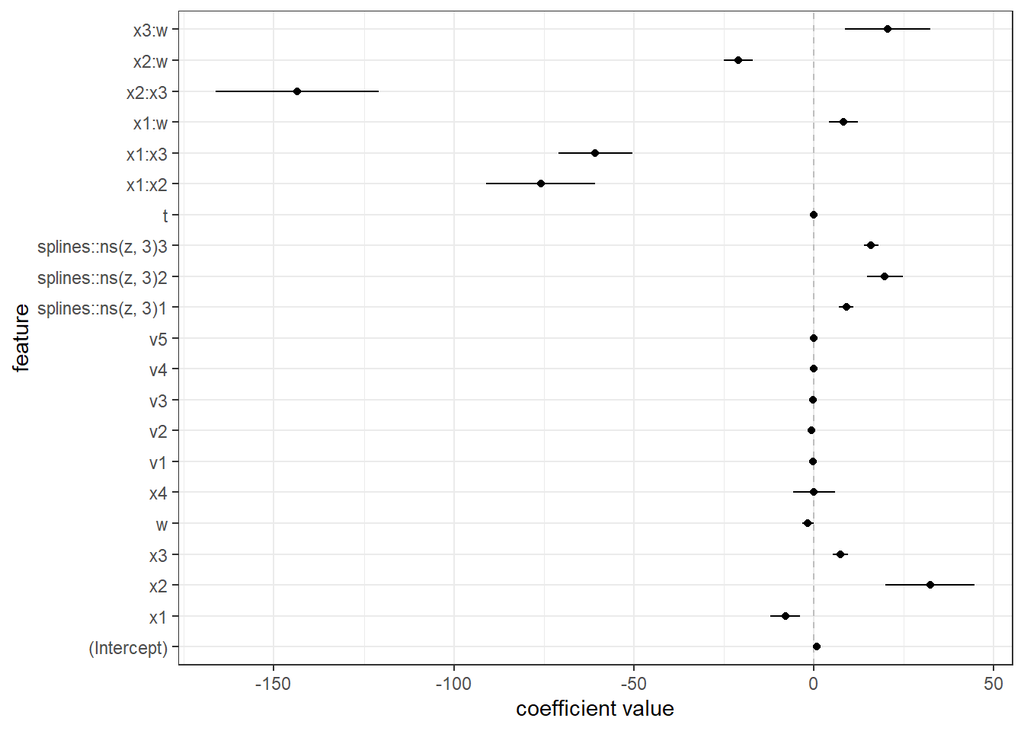

```r
viz_post_coefs <- function(post_means, post_sds, xnames)
{
  tibble::tibble(
    mu = post_means,
    sd = post_sds,
    x = xnames
  ) %>%
    mutate(x = factor(x, levels = xnames)) %>%
    ggplot(mapping = aes(x = x)) +
    geom_hline(yintercept = 0, color = 'grey', linetype = 'dashed') +
    geom_point(mapping = aes(y = mu)) +
    geom_linerange(mapping = aes(ymin = mu - 2 * sd,
                                 ymax = mu + 2 * sd,
                                 group = x)) +
    labs(x = 'feature', y = 'coefficient value') +
    coord_flip() +
    theme_bw()
}

viz_post_coefs(laplace_02$mode[1:ncol(X02)],
               sqrt(diag(laplace_02$var_matrix)[1:ncol(X02)]),
               colnames(X02))
```

### Noise

```r
post_samples <- MASS::mvrnorm(n = 1e4,
                mu = laplace_02$mode,
                Sigma = laplace_02$var_matrix) %>%
    as.data.frame() %>% tibble::as_tibble() %>%
    purrr::set_names(c(sprintf("beta_%02d", 0:(ncol(X02)-1)), "varphi")) %>%
    mutate(sigma = exp(varphi))
post_samples %>% summary()
```

```
##     beta_00           beta_01            beta_02          beta_03
##  Min.   :-0.7556   Min.   :-15.9312   Min.   : 8.004   Min.   : 3.607
##  1st Qu.: 0.6389   1st Qu.: -9.1761   1st Qu.:28.281   1st Qu.: 6.788
##  Median : 0.9549   Median : -7.7908   Median :32.488   Median : 7.524
##  Mean   : 0.9553   Mean   : -7.7817   Mean   :32.425   Mean   : 7.510
##  3rd Qu.: 1.2656   3rd Qu.: -6.3657   3rd Qu.:36.550   3rd Qu.: 8.234
##  Max.   : 2.8351   Max.   : -0.3639   Max.   :55.297   Max.   :11.967
##     beta_04           beta_05            beta_06            beta_07
##  Min.   :-4.5975   Min.   :-10.6386   Min.   :-0.16352   Min.   :-1.4992
##  1st Qu.:-2.0758   1st Qu.: -1.8154   1st Qu.:-0.06811   1st Qu.:-0.6603
##  Median :-1.5316   Median :  0.1990   Median :-0.05038   Median :-0.4772
##  Mean   :-1.5371   Mean   :  0.1551   Mean   :-0.05050   Mean   :-0.4766
##  3rd Qu.:-0.9976   3rd Qu.:  2.0918   3rd Qu.:-0.03272   3rd Qu.:-0.2920
##  Max.   : 1.4798   Max.   : 10.6354   Max.   : 0.05720   Max.   : 0.5404
##     beta_08            beta_09             beta_10             beta_11
##  Min.   :-0.09575   Min.   :-0.673375   Min.   :-0.062852   Min.   : 5.705
##  1st Qu.:-0.04019   1st Qu.:-0.110687   1st Qu.:-0.025434   1st Qu.: 8.416
##  Median :-0.02906   Median : 0.009536   Median :-0.017375   Median : 9.119
##  Mean   :-0.02916   Mean   : 0.008930   Mean   :-0.017302   Mean   : 9.102
##  3rd Qu.:-0.01816   3rd Qu.: 0.130541   3rd Qu.:-0.009138   3rd Qu.: 9.786
##  Max.   : 0.03998   Max.   : 0.711213   Max.   : 0.028443   Max.   :12.818
##     beta_12         beta_13         beta_14            beta_15
##  Min.   :11.28   Min.   :12.24   Min.   :-0.10448   Min.   :-105.58
##  1st Qu.:18.17   1st Qu.:15.34   1st Qu.: 0.04625   1st Qu.: -81.00
##  Median :19.82   Median :16.04   Median : 0.07693   Median : -75.97
##  Mean   :19.81   Mean   :16.04   Mean   : 0.07677   Mean   : -75.95
##  3rd Qu.:21.50   3rd Qu.:16.74   3rd Qu.: 0.10745   3rd Qu.: -70.88
##  Max.   :28.82   Max.   :19.96   Max.   : 0.27528   Max.   : -48.23
##     beta_16          beta_17           beta_18          beta_19
##  Min.   :-80.72   Min.   : 0.6412   Min.   :-189.9   Min.   :-29.05
##  1st Qu.:-64.02   1st Qu.: 6.9881   1st Qu.:-150.9   1st Qu.:-22.26
##  Median :-60.51   Median : 8.3862   Median :-143.4   Median :-20.88
##  Mean   :-60.52   Mean   : 8.3766   Mean   :-143.3   Mean   :-20.86
##  3rd Qu.:-57.03   3rd Qu.: 9.7426   3rd Qu.:-135.7   3rd Qu.:-19.46
##  Max.   :-41.35   Max.   :16.2917   Max.   :-102.6   Max.   :-12.75
##     beta_20           varphi           sigma
##  Min.   :-2.483   Min.   :0.2850   Min.   :1.330
##  1st Qu.:16.534   1st Qu.:0.3425   1st Qu.:1.408
##  Median :20.650   Median :0.3564   Median :1.428
##  Mean   :20.595   Mean   :0.3564   Mean   :1.429
##  3rd Qu.:24.688   3rd Qu.:0.3706   3rd Qu.:1.449
##  Max.   :43.421   Max.   :0.4309   Max.   :1.539
```

```r
mod_9 %>% summary()
```

```
##
## Call:
## lm(formula = y ~ ((x1 + x2 + x3 + w) * (x1 + x2 + x3 + w) + x4 +
##     v1 + v2 + v3 + v4 + v5 + splines::ns(z, 3) + t), data = df_derived)
##
## Residuals:
##     Min      1Q  Median      3Q     Max
## -5.7775 -0.9148 -0.0392  0.8834  6.4361
##
## Coefficients:
##                      Estimate Std. Error t value Pr(>|t|)
## (Intercept)         9.849e-01  4.827e-01   2.040 0.041530 *
## x1                 -8.133e+00  2.075e+00  -3.919 9.39e-05 ***
## x2                  3.287e+01  6.273e+00   5.239 1.90e-07 ***
## x3                  7.522e+00  1.091e+00   6.896 8.52e-12 ***
## w                  -1.626e+00  8.197e-01  -1.983 0.047572 *
## x4                  1.559e-01  2.921e+00   0.053 0.957456
## v1                 -5.077e-02  2.765e-02  -1.837 0.066521 .
## v2                 -4.790e-01  2.788e-01  -1.718 0.086002 .
## v3                 -2.882e-02  1.660e-02  -1.736 0.082795 .
## v4                  7.192e-03  1.801e-01   0.040 0.968152
## v5                 -1.716e-02  1.223e-02  -1.402 0.161041
## splines::ns(z, 3)1  9.315e+00  1.017e+00   9.160  < 2e-16 ***
## splines::ns(z, 3)2  2.031e+01  2.484e+00   8.177 7.20e-16 ***
## splines::ns(z, 3)3  1.625e+01  1.038e+00  15.662  < 2e-16 ***
## t                   7.713e-02  4.676e-02   1.649 0.099304 .
## x1:x2              -7.696e+01  7.713e+00  -9.978  < 2e-16 ***
## x1:x3              -6.136e+01  5.203e+00 -11.793  < 2e-16 ***
## x1:w                8.473e+00  2.081e+00   4.071 4.98e-05 ***
## x2:x3              -1.463e+02  1.149e+01 -12.736  < 2e-16 ***
## x2:w               -2.118e+01  2.075e+00 -10.203  < 2e-16 ***
## x3:w                2.123e+01  5.993e+00   3.542 0.000411 ***
## ---
## Signif. codes:  0 '***' 0.001 '**' 0.01 '*' 0.05 '.' 0.1 ' ' 1
##
## Residual standard error: 1.441 on 1231 degrees of freedom
## Multiple R-squared:  0.6183, Adjusted R-squared:  0.6121
## F-statistic:  99.7 on 20 and 1231 DF,  p-value: < 2.2e-16
```

The residual standard error is 1.441 from `lm()`, which is quite similar to `sigma` whose mean is 1.429.

## Linear models predictions

We use non-Bayesian models for the predictions. We choose `x1` to be the primary input and `w` as the facet variable.

### Create grid

We create a grid of input values where `x1` consists of 101 evenly spaced points between 0 and 0.62 and `w` is 6 evenly spaced points between 0 and 1. We use means for other continuous inputs.

```r
means_inputs <- colMeans(select(df_derived, -c(m, outcome)))
```

```r
viz_grid <- expand.grid(x1 = seq(0, 0.62, length.out = 101),
                        w = seq(0, 1, length.out = 6),
                        x2 = means_inputs['x2'],
                        x3 = means_inputs['x3'],
                        x4 = means_inputs['x4'],
                        v1 = means_inputs['v1'],
                        v2 = means_inputs['v2'],
                        v3 = means_inputs['v3'],
                        v4 = means_inputs['v4'],
                        v5 = means_inputs['v5'],
                        z = means_inputs['z'],
                        t = means_inputs['t'],
                        KEEP.OUT.ATTRS = FALSE,
                        stringsAsFactors = FALSE) %>%
  as.data.frame() %>% tibble::as_tibble()
```

### Predictions

```r
tidy_predict <- function(mod, xnew)
{
  pred_df <- predict(mod, xnew, interval = "confidence") %>%
    as.data.frame() %>% tibble::as_tibble() %>%
    dplyr::select(pred = fit, ci_lwr = lwr, ci_upr = upr) %>%
    bind_cols(predict(mod, xnew, interval = 'prediction') %>%
                as.data.frame() %>% tibble::as_tibble() %>%
                dplyr::select(pred_lwr = lwr, pred_upr = upr))

  xnew %>% bind_cols(pred_df)
}
```

```r
pred_lm_06 <- tidy_predict(mod_6, viz_grid)
pred_lm_09 <- tidy_predict(mod_9, viz_grid)
```

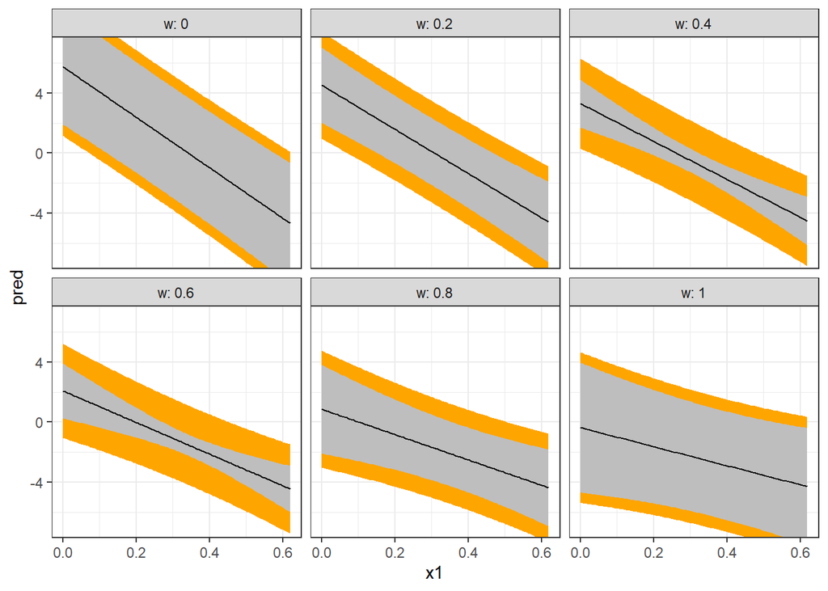

```r
pred_lm_06 %>%
  ggplot(mapping = aes(x = x1)) +
  geom_ribbon(mapping = aes(ymin = pred_lwr, ymax = pred_upr),
              fill = 'orange') +
  geom_ribbon(mapping = aes(ymin = ci_lwr, ymax = ci_upr),
              fill = 'grey') +
  geom_line(mapping = aes(y = pred),
            color = 'black') +
  coord_cartesian(ylim = c(-7, 7)) +
  facet_wrap(~w, labeller = "label_both") +
  theme_bw()
```

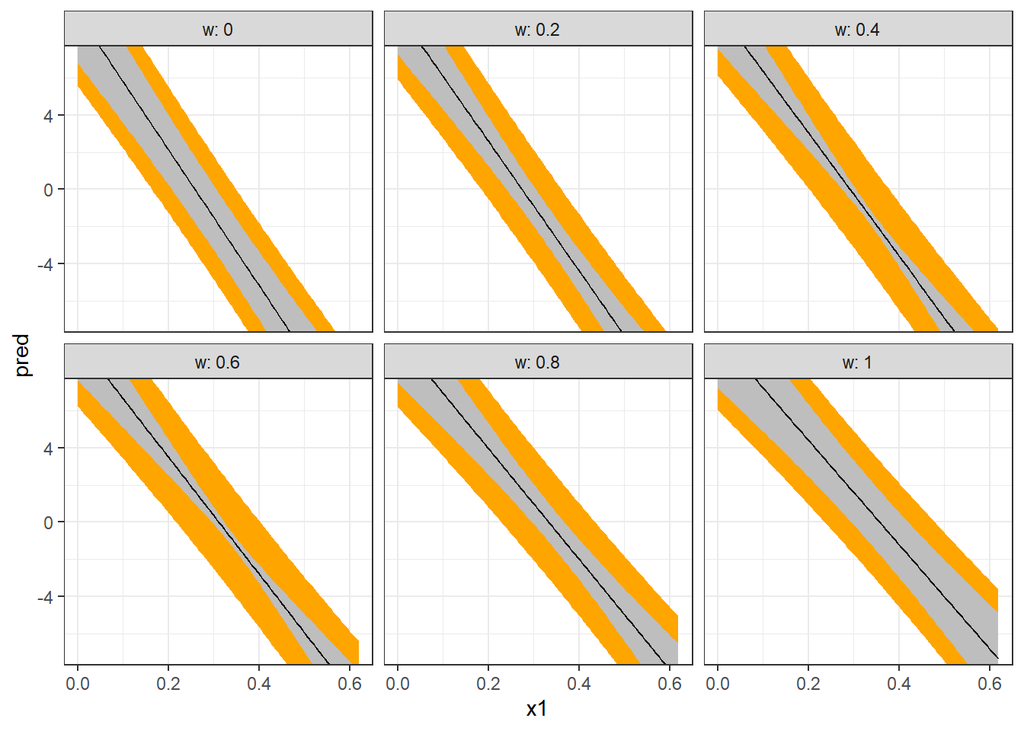

```r
pred_lm_09 %>%
  ggplot(mapping = aes(x = x1)) +
  geom_ribbon(mapping = aes(ymin = pred_lwr, ymax = pred_upr),
              fill = 'orange') +
  geom_ribbon(mapping = aes(ymin = ci_lwr, ymax = ci_upr),
              fill = 'grey') +
  geom_line(mapping = aes(y = pred),
            color = 'black') +
  coord_cartesian(ylim = c(-7, 7)) +
  facet_wrap(~w, labeller = "label_both") +
  theme_bw()
```

The trends are consistent between the 2 selected models.

## Train/Tune with resampling

### Linear models

We use 5 fold cross-validation with 5 repeats to train the linear models.

```r
my_ctrl <- trainControl(method = 'repeatedcv', number = 5, repeats = 5)
```

```r
my_metric <- 'RMSE'
```

```r
# Additive features using "base feature" set
set.seed(2022)
mod_lm_1 <- train(y ~ x1 + x2 + x3 + x4 + v1 + v2 + v3 + v4 + v5 + m,
                        data = df,
                        method = "lm",
                        metric = my_metric,
                        trControl = my_ctrl)
```

```r
# Additive features using "expanded feature" set
set.seed(2022)
mod_lm_2 <- train(y ~ x1 + x2 + x3 + x4 + v1 + v2 + v3 + v4 + v5 + m + w + z + t,
                        data = df_derived,
                        method = "lm",
                        metric = my_metric,
                        trControl = my_ctrl)
```

```r
# Pair-wise interactions between the continuous features
set.seed(2022)
mod_lm_3 <- train(y ~ (x1 + x2 + x3 + x4 + v1 + v2 + v3 + v4 + v5 + w + z + t) * (x1 + x2 + x3 + x4 + v1 + v2 + v3 + v4 + v5 + w + z + t),
                        data = df_derived,
                        method = "lm",
                        metric = my_metric,
                        trControl = my_ctrl)
```

```r
# Own model
set.seed(2022)
mod_lm_4 <- train(y ~ ((x1 + x2 + x3 + w) * (x1 + x2 + x3 + w) + x4 + v1 + v2 + v3 + v4 + v5 + splines::ns(z, 3) + t),
                        data = df_derived,
                        method = "lm",
                        metric = my_metric,
                        trControl = my_ctrl)
```

### Regularized regression with elastic net

In the first model, we interact the categorical variable with all pair wise interactions of the continuous features.

```r
set.seed(2022)
train( y ~ m * (x1 + x2 + x3 + x4 + v1 + v2 + v3 + v4 + v5) * (x1 + x2 + x3 + x4 + v1 + v2 + v3 + v4 + v5), data = df_derived,
    method = 'glmnet',
    metric = my_metric,
    preProcess = c("center", "scale"),
    trControl = my_ctrl) %>% readr::write_rds("elastic_net_01_model.rds")
```

In the second model, we add the categorical features to `mod_6`.

```r
set.seed(2022)
train( y ~ m * (x1 + x2 + x3 + x4 + v1 + v2 + v3 + v4 + v5 + w + z + t) * (x1 + x2 + x3 + x4 + v1 + v2 + v3 + v4 + v5 + w + z + t), data = df_derived,
    method = 'glmnet',
    metric = my_metric,
    preProcess = c("center", "scale"),
    trControl = my_ctrl) %>% readr::write_rds("elastic_net_02_model.rds")
```

In the third model, we add the categorical features to `mod_9`.

```r
set.seed(2022)
train( y ~ m * ((x1 + x2 + x3 + w) * (x1 + x2 + x3 + w) + x4 + v1 + v2 + v3 + v4 + v5 + splines::ns(z, 3) + t), data = df_derived,
    method = 'glmnet',
    metric = my_metric,
    preProcess = c("center", "scale"),
    trControl = my_ctrl) %>% readr::write_rds("elastic_net_03_model.rds")
```

```r
enet_01 <- readr::read_rds("elastic_net_01_model.rds")
enet_02 <- readr::read_rds("elastic_net_02_model.rds")
enet_03 <- readr::read_rds("elastic_net_03_model.rds")
```

### Neural network

In the first model, we use the interaction of the categorical input with all base continuous inputs.

```r
set.seed(2022)
train(y ~ m * (x1 + x2 + x3 + x4 + v1 + v2 + v3 + v4 + v5),
      data = df_derived,
      method = 'nnet',
      metric = my_metric,
      preProcess = c("center", "scale"),
      trControl = my_ctrl,
      trace = FALSE) %>% readr::write_rds("neural_net_01_model.rds")
```

In the second model, we add the categorical features to `mod_9`.

```r
set.seed(2022)
train(y ~ m * ((x1 + x2 + x3 + w) * (x1 + x2 + x3 + w) + x4 + v1 + v2 + v3 + v4 + v5 + splines::ns(z, 3) + t),
      data = df_derived,
      method = 'nnet',
      metric = my_metric,
      preProcess = c("center", "scale"),
      trControl = my_ctrl,
      trace = FALSE) %>% readr::write_rds("neural_net_02_model.rds")
```

```r
nnet_01 <- readr::read_rds("neural_net_01_model.rds")
nnet_02 <- readr::read_rds("neural_net_02_model.rds")
```

### Random forest

In the first model, we use the interaction of the categorical input with all base continuous inputs.

```r
set.seed(2022)
train(y ~ m * (x1 + x2 + x3 + x4 + v1 + v2 + v3 + v4 + v5),
      data = df_derived,
      method = 'rf',
      metric = my_metric,
      trControl = my_ctrl,
      importance=TRUE) %>% readr::write_rds("rf_01_model.rds")
```

In the second model, we use the setting in `mod_9`.

```r
set.seed(2022)
train(y ~ ((x1 + x2 + x3 + w) * (x1 + x2 + x3 + w) + x4 + v1 + v2 + v3 + v4 + v5 + splines::ns(z, 3) + t),
      data = df_derived,
      method = 'rf',
      metric = my_metric,
      trControl = my_ctrl,
      importance=TRUE) %>% readr::write_rds("rf_02_model.rds")
```

```r
r_forest_01 <- readr::read_rds("rf_01_model.rds")
r_forest_02 <- readr::read_rds("rf_02_model.rds")
```

### Gradient boosted tree

In the first model, we use the interaction of the categorical input with all base continuous inputs.

```r
set.seed(2022)
train(y ~ m * (x1 + x2 + x3 + x4 + v1 + v2 + v3 + v4 + v5),
      data = df_derived,
      method = 'xgbTree',
      metric = my_metric,
      trControl = my_ctrl,
      verbosity = 0) %>% readr::write_rds("boosted_tree_01_model.rds")
```

In the following settings.

```r
set.seed(2022)
train(y ~ (splines::ns(x1, 3) + x2 + x3) * (splines::ns(x1, 3) + x2 + x3) + splines::ns(w, 3) + splines::ns(z, 3) + splines::ns(t, 3),
      data = df_derived,
      method = 'xgbTree',
      metric = my_metric,
      trControl = my_ctrl,
      verbosity = 0) %>% readr::write_rds("boosted_tree_02_model.rds")
```

```r
xgb_01 <- readr::read_rds("boosted_tree_01_model.rds")
xgb_02 <- readr::read_rds("boosted_tree_02_model.rds")
```

### Support Vector Machines

We use pair wise continuous features.

```r
set.seed(2022)
train(y ~ (x1 + x2 + x3 + x4 + v1 + v2 + v3 + v4 + v5 + w + z + t) * (x1 + x2 + x3 + x4 + v1 + v2 + v3 + v4 + v5 + w + z + t),
      data = df_derived,
      method = "svmLinear",
      preProcess = c("center", "scale"),
      trControl = my_ctrl) %>% readr::write_rds("support_vector_reg_model.rds")
```

```r
svm_reg <- readr::read_rds("support_vector_reg_model.rds")
```